# **Predictive Analysis of Wine Ratings**

## **Spring 2024 Data Science Project**

#### **Member 1: Jesse Shen, Contribution: %100**

### **1. Introduction**

This project aims to explore the world of wines, focusing specifically on predicting wine ratings based on attributes such as the country of origin, price, and variety of grapes used. Our primary aim is to utilize regression techniques to predict the quality of wines as rated by experts, measured on a scale from 1 to 100 points. Understanding which factors most significantly influence wine ratings can provide valuable insights for consumers, wineries, and marketers alike.

By analyzing the relationships between the geographical location, price, type of grapes, and the resulting quality ratings, we hope to uncover patterns that could help predict wine quality more accurately. This analysis not only serves to enhance the consumer's purchasing decisions but also assists wineries in positioning their products strategically in the market. Through this project, we intend to apply data science methodologies to make meaningful predictions that could potentially influence marketing strategies and consumer choices in the wine industry.

### **2. Data Curation**

Dataset source: https://www.kaggle.com/datasets/zynicide/wine-reviews

From this link you'll find the dataset we'll be using for this study. In this dataset, we'll find these variables:

- **Unnamed: 0**: An index column that appears to be redundant as it simply enumerates the entries.
- **Country**: The country where the wine originates. This can influence the wine's style and flavor profile due to regional climatic conditions and winemaking traditions.
- **Description**: A textual description of each wine, which often includes sensory data like taste notes, smell, and recommended pairings.
- **Designation**: The specific vineyard or area of the vineyard where the grapes for the wine were grown. This can provide insight into the microclimatic conditions affecting the grape's quality.
- **Points**: The rating given to the wine, on a scale from 1 to 100. This score is a critical measure of the wine's quality as assessed by wine experts.
- **Price**: The retail price of the wine, which can be an indicator of its perceived quality and market positioning.
- **Province**: The province or state where the wine comes from, offering more granularity on its geographical origin within a country.
- **Region_1**: A more specific region within the province where the wine is produced
- **Region_2**: An even more specific classification within Region_1
- **Variety**: The type of grape(s) used to make the wine, which is a primary factor in determining the style and flavor profile of the wine.
- **Winery**: The winery that produced the wine, indicating the brand or producer behind the wine.

We'll be putting this data into a dataframe so that we can manipulate and utilize this data to answer the question we are trying to solve. First we'll begin by importing the necessary tools below.

###### **Imports**

```python
import pandas as pd
from scipy import stats
import matplotlib.pyplot as plt
import seaborn as sns
from sklearn.linear_model import LinearRegression
from sklearn.model_selection import train_test_split
from sklearn.metrics import mean_squared_error, r2_score
import numpy as np
from sklearn.preprocessing import StandardScaler, OneHotEncoder
from sklearn.preprocessing import PolynomialFeatures
from sklearn.impute import SimpleImputer
from sklearn.linear_model import Ridge
from sklearn.pipeline import make_pipeline
from sklearn.compose import ColumnTransformer
from sklearn.pipeline import Pipeline
```

Next, we'll load the dataset into a dataframe so that we can view the data and make any necessary changes to the data. We have to make sure we correctly read the csv file, avoiding issues when running into ',' from entries in the description column.

```python
wine_df = pd.read_csv('wine.csv', on_bad_lines='skip', engine='python')

wine_df.head(10) # Looking at the first 10 rows of the dataframe we've created
```

|  | Unnamed: 0 | country | description | designation | points | price | province | region_1 | region_2 | variety | winery |
| --- | --- | --- | --- | --- | --- | --- | --- | --- | --- | --- | --- |
| 0 | 0 | US | This tremendous 100% varietal wine hails from ... | Martha's Vineyard | 96 | 235.0 | California | Napa Valley | Napa | Cabernet Sauvignon | Heitz |
| 1 | 1 | Spain | Ripe aromas of fig, blackberry and cassis are ... | Carodorum Selección Especial Reserva | 96 | 110.0 | Northern Spain | Toro | NaN | Tinta de Toro | Bodega Carmen Rodríguez |
| 2 | 2 | US | Mac Watson honors the memory of a wine once ma... | Special Selected Late Harvest | 96 | 90.0 | California | Knights Valley | Sonoma | Sauvignon Blanc | Macauley |
| 3 | 3 | US | This spent 20 months in 30% new French oak, an... | Reserve | 96 | 65.0 | Oregon | Willamette Valley | Willamette Valley | Pinot Noir | Ponzi |
| 4 | 4 | France | This is the top wine from La Bégude, named aft... | La Brûlade | 95 | 66.0 | Provence | Bandol | NaN | Provence red blend | Domaine de la Bégude |
| 5 | 5 | Spain | Deep, dense and pure from the opening bell, th... | Numanthia | 95 | 73.0 | Northern Spain | Toro | NaN | Tinta de Toro | Numanthia |
| 6 | 6 | Spain | Slightly gritty black-fruit aromas include a s... | San Román | 95 | 65.0 | Northern Spain | Toro | NaN | Tinta de Toro | Maurodos |
| 7 | 7 | Spain | Lush cedary black-fruit aromas are luxe and of... | Carodorum Único Crianza | 95 | 110.0 | Northern Spain | Toro | NaN | Tinta de Toro | Bodega Carmen Rodríguez |
| 8 | 8 | US | This re-named vineyard was formerly bottled as... | Silice | 95 | 65.0 | Oregon | Chehalem Mountains | Willamette Valley | Pinot Noir | Bergström |
| 9 | 9 | US | The producer sources from two blocks of the vi... | Gap's Crown Vineyard | 95 | 60.0 | California | Sonoma Coast | Sonoma | Pinot Noir | Blue Farm |

Let's first get rid of the redundant column **Unnamed: 0**, we'll do this in the code below.

```python
wine_df = wine_df.drop(columns=['Unnamed: 0'])

wine_df.head() # View the edited dataframe
```

|  | country | description | designation | points | price | province | region_1 | region_2 | variety | winery |
| --- | --- | --- | --- | --- | --- | --- | --- | --- | --- | --- |
| 0 | US | This tremendous 100% varietal wine hails from ... | Martha's Vineyard | 96 | 235.0 | California | Napa Valley | Napa | Cabernet Sauvignon | Heitz |
| 1 | Spain | Ripe aromas of fig, blackberry and cassis are ... | Carodorum Selección Especial Reserva | 96 | 110.0 | Northern Spain | Toro | NaN | Tinta de Toro | Bodega Carmen Rodríguez |
| 2 | US | Mac Watson honors the memory of a wine once ma... | Special Selected Late Harvest | 96 | 90.0 | California | Knights Valley | Sonoma | Sauvignon Blanc | Macauley |
| 3 | US | This spent 20 months in 30% new French oak, an... | Reserve | 96 | 65.0 | Oregon | Willamette Valley | Willamette Valley | Pinot Noir | Ponzi |
| 4 | France | This is the top wine from La Bégude, named aft... | La Brûlade | 95 | 66.0 | Provence | Bandol | NaN | Provence red blend | Domaine de la Bégude |

### **3. Exploratory Data Analysis**

Now we can begin understanding our data. Let's try to answer questions like:

What are the main characteristics of your dataset? How many features and entries are there? Is a feature over-represented? Are features correlated? Are there outliers? Identify the attributes that will affect our analysis technique.

Below, we'll start off by looking at our total rows and categories.

```python
num_rows, num_categories = wine_df.shape

print('Total Rows:', num_rows)
print('Total Categories:', num_categories)
```

```
Total Rows: 150930
Total Categories: 10
```

We can see that we have about 150930 entries, we'll need to keep this number in mind, because any category with less than this many entries means we have missing values, we want to avoid using categories with a lot of missing values.

Let's check below to see what categories will be useful in our analysis.

```python
info = wine_df.count()

info
```

```
country        150925
description    150930
designation    105195
points         150930
price          137235
province       150925
region_1       125870
region_2        60953
variety        150930
winery         150930
dtype: int64
```

Let's create a graph so we can visualize what we're working with.

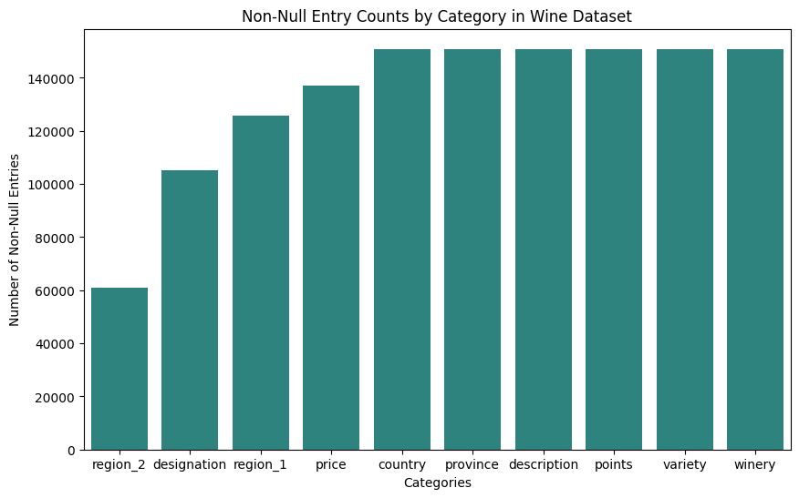

```python
nonnull_counts = wine_df.notnull().sum()

sorted_counts = nonnull_counts.sort_values()

plt.figure(figsize=(10, 6))
sns.barplot(x=sorted_counts.index, y=sorted_counts.values, palette='viridis', hue=1, legend=False)

plt.xlabel('Categories')
plt.ylabel('Number of Non-Null Entries')
plt.title('Non-Null Entry Counts by Category in Wine Dataset')

plt.show()
```

```python
wine_df = wine_df.dropna(subset=['price'])
wine_df = wine_df.dropna(subset=['country'])

info = wine_df.count()

info
```

```
country        137230
description    137230
designation     94919
points         137230
price          137230
province       137230
region_1       114393
region_2        60704
variety        137230
winery         137230
dtype: int64
```

Now we have 137230 entries that we can work with in order to make our regression model that will predict ratings of wines. Here is the new data distribution visualization with our cleaned dataset.

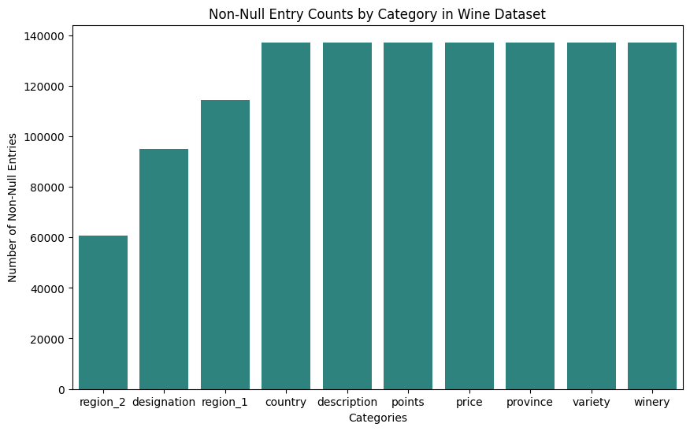

```python
nonnull_counts = wine_df.notnull().sum()

sorted_counts = nonnull_counts.sort_values()

plt.figure(figsize=(10, 6))
sns.barplot(x=sorted_counts.index, y=sorted_counts.values, palette='viridis', hue=1, legend=False)

plt.xlabel('Categories')
plt.ylabel('Number of Non-Null Entries')
plt.title('Non-Null Entry Counts by Category in Wine Dataset')

plt.show()
```

Let's get rid of some columns that we won't be using

```python
wine_df = wine_df.drop(['region_2', 'designation', 'region_1', 'description', 'winery'], axis=1)

wine_df.head() # View the edited dataframe
```

|  | country | points | price | province | variety |
| --- | --- | --- | --- | --- | --- |
| 0 | US | 96 | 235.0 | California | Cabernet Sauvignon |
| 1 | Spain | 96 | 110.0 | Northern Spain | Tinta de Toro |
| 2 | US | 96 | 90.0 | California | Sauvignon Blanc |
| 3 | US | 96 | 65.0 | Oregon | Pinot Noir |
| 4 | France | 95 | 66.0 | Provence | Provence red blend |

Next, we'd like to understand the outliers in price, to do this we're going to create box and whisker plots that will help us derive some necessary conclusions about price. Here is how we do that.

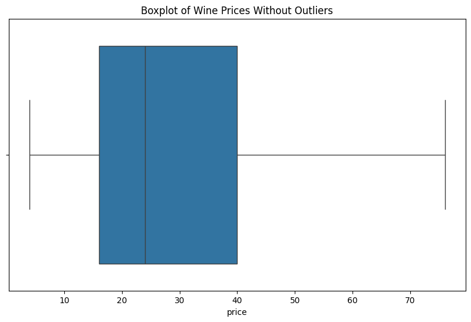

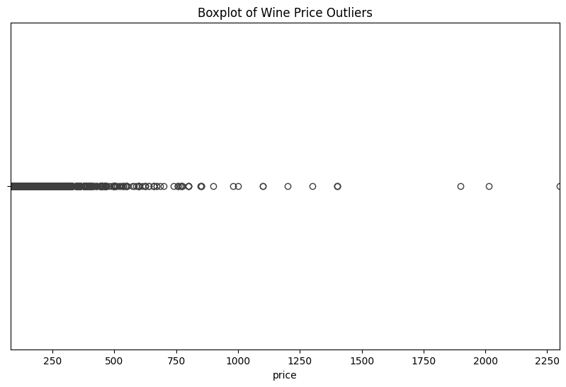

```python
def detect_outliers(df, column):
    Q1 = df[column].quantile(0.25)
    Q3 = df[column].quantile(0.75)
    IQR = Q3 - Q1
    lower_bound = Q1 - 1.5 * IQR
    upper_bound = Q3 + 1.5 * IQR

    outliers = df[(df[column] < lower_bound) | (df[column] > upper_bound)]
    return outliers, lower_bound, upper_bound

price_outliers, price_lb, price_ub = detect_outliers(wine_df, 'price')
points_outliers, points_lb, points_ub = detect_outliers(wine_df, 'points')

plt.figure(figsize=(10, 6))
sns.boxplot(x=wine_df['price'], showfliers=False)
plt.title('Boxplot of Wine Prices Without Outliers')
plt.show()

plt.figure(figsize=(10, 6))
sns.boxplot(x=wine_df['price'])
plt.xlim(wine_df['price'].quantile(.95), wine_df['price'].max())
plt.title('Boxplot of Wine Price Outliers')
plt.show()
```

We calculated the necessary values for a boxplot of the 'prices' category. Due to a huge range of prices, in order to properly visualize the outliers and box plot values, we seperate the outliers from the actual box plot without outliers. From the visualizations we can conclude that there are many many outliers in prices of wine. While the median sits near 25, and a max value near 75, the prices can range up to 2300. This makes sense considering some wines are extremely valuable and could have exteremly high value comapared to normal wine bought from stores. We will need to consider this when conducting tests, as a large outlier like 2300 can easily change the general results of a test.

We are going to cap the outliers at the 95th percentile, the goal of this is to limit the effect of extreme values that can skew our data distribution and statistical analysis, leading to more stable mean, variance, and other statistical measures.

```python
# Calculate the 95th percentile value
price_95th_percentile = wine_df['price'].quantile(0.95)

# Replace values above the 95th percentile with the 95th percentile value
wine_df['price'] = wine_df['price'].apply(lambda x: min(x, price_95th_percentile))
```

Now let's revisualize the price data

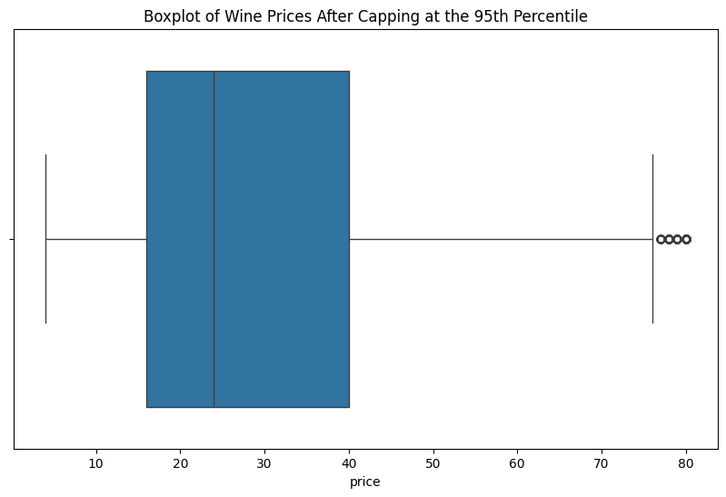

```python
# Plotting the boxplot after capping
plt.figure(figsize=(10, 6))
sns.boxplot(x=wine_df['price'])
plt.title('Boxplot of Wine Prices After Capping at the 95th Percentile')
plt.show()
```

#### **ANOVA Test**

Now, let's conduct a hypothesis test on the data. We are going to perform an ANOVA test, here are the conditions:

HO: The average wine points are the same across the top three countries. The country of origin does not significantly affect the wine's rating.

HA: There is a significant difference in the average wine points between at least two of the top three countries. The country of origin does have an effect on the wine's rating.

Using an alpha value of .05

Step 1: Find top three countries based on most entries

```python
top_countries = wine_df['country'].value_counts().head(3)
top_countries
```

```
country
US        62139
Italy     18784
France    14785
Name: count, dtype: int64
```

Step 2: Create table that includes the top three countries and their points

```python
us_points = wine_df[(wine_df['country'] == 'US')]['points']
italy_points = wine_df[(wine_df['country'] == 'Italy')]['points']
france_points = wine_df[(wine_df['country'] == 'France')]['points']
```

Step 3: Calculate p-value using ANOVA test

```python
anova_result = stats.f_oneway(us_points, italy_points, france_points)

p_value = anova_result[1]

print(p_value)
```

```
9.265496315907573e-222
```

#### ANOVA Test Conclusion

With a calculated P-value of 9.265496315907573e-222, which is much smaller than .05, we can reject the null hypothesis and turn to the Alternative hypothesis. This means there is statistically significant evidence to suggest that there are differences in the average wine points among the top three countries (US, Italy, France). The extremely small p-value suggests that the country of origin does have a significant effect on the wine's rating.

Ha: There is a significant difference in the average wine points between at least two of the top three countries. The country of origin does have an effect on the wine's rating.

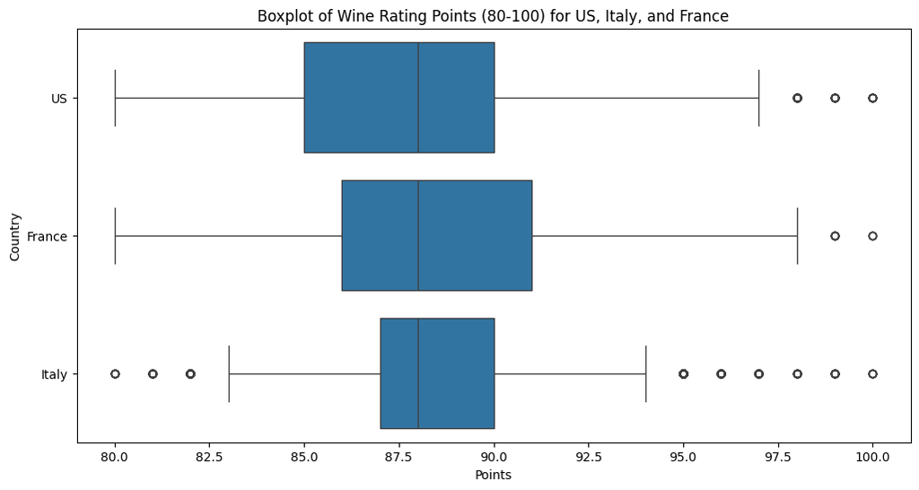

```python
top_countries_df = wine_df[wine_df['country'].isin(['US', 'Italy', 'France'])]

plt.figure(figsize=(12, 6))
sns.boxplot(x='points', y='country', data=top_countries_df)
plt.title('Boxplot of Wine Rating Points (80-100) for US, Italy, and France')
plt.xlabel('Points')
plt.ylabel('Country')
plt.show()
```

The results of the ANOVA test, with a p-value of 9.265496315907573e-222, indicate that there are statistically significant differences in the average points awarded to wines from the top three wine-producing countries: the United States, Italy, and France. Despite the visual similarity in median ratings across these countries as observed in the boxplot, the statistical analysis confirms that the country of origin does indeed influence the wine's rating.

This finding suggests that subtle yet statistically significant factors associated with each country—perhaps related to grape varieties, or wine-making practices—impact the quality as perceived by wine experts. The median ratings, while visually close, mask underlying differences.

### **4. Primary Analysis**

Technique Chosen: Regression Analysis

Reasoning:

Given the conlusions we derived form our dataset and the specific questions we aim to answer, regression analysis emerges as the most suitable machine learning technique for this study. Our primary goal is to predict wine quality, which is quantitatively represented by the 'points' variable in our dataset—which is a continuous outcome ranging from 1 to 100. Here are the key reasons for selecting regression:

- The structure of our dataset supports regression analysis. We have several potential predictor variables (price, country, variety), and our target variable (wine ratings) is continuous, which is ideal for regression.
- Preliminary statistical tests, including the ANOVA, highlighted the influence of country of origin on wine ratings. This insight supports the use of regression to further explore how location and other features affect wine quality, espescially aftering understanding that there are more hidden attributes that are affecting wine quality alongside country of origin.

##### **Regression Model**

**Step 1: Data Preparation**

Ensure that data is ready for modeling:

We are going to want to use one-hot encoding in order to utilize the categories that are not numerical. Let's also make sure no NaN values are present in the dataset.

```python
wine_df_encoded = pd.get_dummies(wine_df)
```

**Step 2: Model Selection**

Now let's intialize a regression model

```python
random_state = 42
np.random.seed(random_state)

# First, check and handle NaNs in the entire DataFrame
imputer = SimpleImputer(strategy='median')
wine_df_encoded_imputed = imputer.fit_transform(wine_df_encoded)
wine_df_encoded_imputed = pd.DataFrame(wine_df_encoded_imputed, columns=wine_df_encoded.columns)

# Split the data into features and target
X = wine_df_encoded_imputed.drop('points', axis=1)
y = wine_df_encoded_imputed['points']

# Split the data into training and testing sets
X_train, X_test, y_train, y_test = train_test_split(X, y, test_size=0.2, random_state=random_state)

scaler = StandardScaler()
X_train_scaled = scaler.fit_transform(X_train)
X_test_scaled = scaler.transform(X_test)

ridge_model = Ridge(alpha=1.0)
ridge_model.fit(X_train_scaled, y_train)
```

```
Ridge()
```

**Step 3: Model Evaluation**

Evaluate the model using metrics such as RMSE and R-squared:

```python
# Predict and evaluate
y_pred_ridge = ridge_model.predict(X_test_scaled)
mse_ridge = mean_squared_error(y_test, y_pred_ridge)
rmse_ridge = mse_ridge ** 0.5
r2_ridge = r2_score(y_test, y_pred_ridge)

print(f'RMSE: {rmse_ridge}')
print(f'R-squared: {r2_ridge}')
```

```
RMSE: 2.4421421987998753
R-squared: 0.425075894103324
```

Our RMSE of 2.44 suggests that our model's predictions are within about 2.44 points of the actual wine ratings, which is quite reasonable given the scale of wine ratings typically ranges from 80 to 100.

An R^2 value of about 0.425 means that approximately 42.5% of the variance in wine ratings is explained by our model. While this isn't extremely high, it does show that the model has a moderate level of predictive power.

### 5. Visualization

Let's create a feature importance plot, we can begin below by creating a pipeline.

```python
# Define the preprocessing for numeric and categorical features
numeric_features = ['price']
categorical_features = ['country', 'province', 'variety']

preprocessor = ColumnTransformer(
    transformers=[
        ('num', StandardScaler(), numeric_features),
        ('cat', OneHotEncoder(handle_unknown='ignore'), categorical_features),
    ])

# Instantiate the pipeline
pipeline = Pipeline([
    ('preprocessor', preprocessor),
    ('regressor', Ridge())
])

# Debugging step
try:
    # Check the output of the preprocessor on a small subset
    debug_transformed = preprocessor.fit_transform(wine_df.head())
    print("Preprocessing successful, transformed shape:", debug_transformed.shape)
except Exception as e:
    print("Error during preprocessing:", e)

# If the above step is successful, start fitting the model
try:
    X = wine_df.drop('points', axis=1)
    y = wine_df['points']
    pipeline.fit(X, y)
    print("Model fitting successful")
except Exception as e:
    print("Error during model fitting:", e)
```

```
Preprocessing successful, transformed shape: (5, 13)
Model fitting successful
```

Now let's plot the top ten most important features based on our regression model.

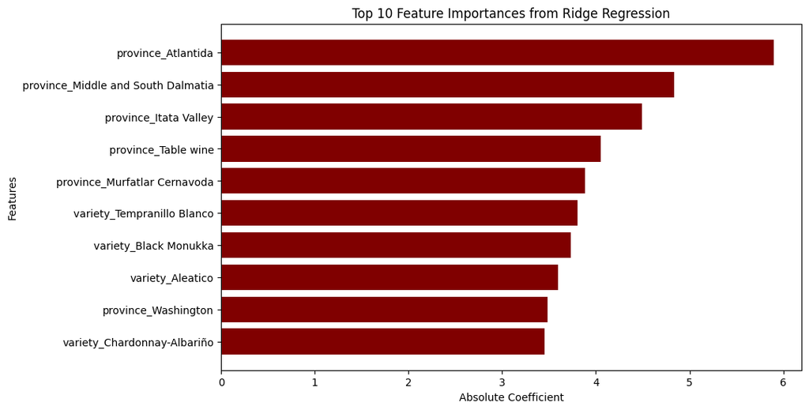

```python
# Extracting feature names from OneHotEncoder and combining them with numeric features
cat_feature_names = pipeline.named_steps['preprocessor'].transformers_[1][1].get_feature_names_out()
feature_names = np.concatenate([numeric_features, cat_feature_names])

# Extracting coefficients from the Ridge regressor in the pipeline
coefficients = pipeline.named_steps['regressor'].coef_

# Create a feature importance dataframe and plot
importance = pd.DataFrame({'Feature': feature_names, 'Coefficient': coefficients})
importance['Absolute Coefficient'] = importance['Coefficient'].abs()
importance_sorted = importance.sort_values(by='Absolute Coefficient', ascending=False).head(10)

plt.figure(figsize=(10, 6))
plt.barh(importance_sorted['Feature'], importance_sorted['Absolute Coefficient'], color='maroon')
plt.xlabel('Absolute Coefficient')
plt.ylabel('Features')
plt.title('Top 10 Feature Importances from Ridge Regression')
plt.gca().invert_yaxis()  # Display the highest importance at the top
plt.show()
```

This plot shows the top 10 features that have the most significant impact on wine ratings according to the Ridge regression model. Here's what we can observe and explain:

Provincial Influence: Various provinces like "Atlantida," "Middle and South Dalmatia," and others seem to have a significant impact on the ratings, suggesting that geographic origin within a country can substantially influence wine quality perceptions.

Varietal Impact: Grape varieties such as "Tempranillo Blanco," "Black Monukka," and others also play a crucial role, highlighting the importance of grape type in determining the quality of wine.

#### **Visualisation Actual vs. Predicted**

Below is the code used to visualize model's prediction accuracy

[figure not shown]

```python
# Predict using the pipeline
y_pred = pipeline.predict(X)

plt.figure(figsize=(10, 6))
plt.scatter(y, y_pred, alpha=0.3)  # Increase alpha for less transparency if needed
plt.plot([y.min(), y.max()], [y.min(), y.max()], 'k--', lw=4)
plt.xlabel('Actual Points')
plt.ylabel('Predicted Points')
plt.title('Actual vs. Predicted Wine Ratings')
plt.legend(['Perfect Prediction', 'Predictions'])
plt.grid(True)
plt.show()
```

This scatter plot compares the actual wine ratings (x-axis) to the ratings predicted by the model (y-axis), with a perfect prediction line for reference:

### **6. Insights and Conclusions**

This project applied machine learning techniques to predict wine ratings based on various characteristics, achieving an RMSE of 2.44 and an R^2 of 0.425. The analysis revealed that specific provinces and grape varieties are significant predictors of wine quality, suggesting that geographic and climatic factors play a crucial role in wine production.

For wine producers, these insights emphasize the importance of region-specific branding and could guide decisions on which grape to grow for their wine. Additionally, marketers might leverage these findings to promote wines from higher-rated regions more effectively.

**Valuable conclusions**:

For informed readers, this study highlights the complexity of wine ratings and may introduce further exploration into other factors affecting wine quality. Future research could enhance these findings by integrating more defined data or exploring consumer taste preferences in more detail.

In conclusion, this project not only provides a predictive base for assessing wine quality but also increases our understanding of the diverse factors that influence wine ratings, which offer valuable insights to both consumers and the wine industry.